# RNA-Seq Data Analysis, Helsinki University, 21-25th October 2019

Nicolas Delhomme, Bastian Schiffthaler

2020-11-21

# Introduction

## About the tutorial

This tutorial adresses several aspect of an RNA-Seq data analysis. First, it deals with data pre-processing (a process rather agnostic to the type of NGS analysis, *i.e.* it would also be valid for ChIP-Seq or DNA-Seq). That part of the tutorial introduces the use of the command line (specifically the bourne-again shell: bash) and several software tools to prepare sequencing data for downstrem analysis. Specifically, we will be covering quality control, rRNA sorting, quality trimming, and expression quantification. For the latter, either by read mapping + feature summarization or by pseudo-alignment; or both . If these terms don’t mean much yet, hopefully they will by the end of the practical. "Read mapping and feature summarisation" deals with the manipulation of alignment files (in BAM format) and the obtention and manipulation of genomic (and genic) annotations to subsequently combine them to obtain a *raw count table*[^1]. The pseudo-alignment method directly generates such a count table. This count table is the necessary minimal input for a Differential Expression analysis, which is the ultimate step in this tutorial.

The goals of the tutorial are:

- First part
  - become familiar with the Linux command line
  - be able to carry out quality control and necessary pre-processing steps of sequencing data
- Second part
  - become familiar with the R environment
  - develop familiarity with R/Bioconductor packages for high-throughput analysis
- Third part
  - become familiar with the Differential Expression type of analysis

## Main softwares of interest

1. `FastQC` - Sequence data quality control

2. `SortMeRNA` - rRNA filtering
3. `Trimmomatic` - Low quality read and adapter trimming
4. `STAR` - Read mapping
5. `HTSeq` and `kallisto` - Feature summarization

## Main R/Bioconductor packages of interest

Bioconductor is a collection of R packages for the analysis and comprehension of high-throughput genomic data. Among these, we will focus on a few of them principally: `GenomicAlignments`, `GenomicFeatures` and `GenomicRanges`. We will look at these packages (i) as an example to understand what the process of **feature summarization** is (*i.e.* taking a look under the hood) and (ii) as an introduction to computational optimisation in R.

We will, in addition, use two packages for Differential Expression data analysis: `tximport` and `DESeq2`.

### A word on High-throughput sequence analysis

Recent technological developments introduced high-throughput sequencing approaches. A variety of experimental protocols and analysis workflows address gene expression, regulation, and encoding of genetic variants. Experimental protocols produce a large number (tens to hundreds of millions per sample) of short (*e.g.*: 35-250, single or paired-end) nucleotide sequences. These are aligned to a reference or other genome or transcriptome. Analysis workflows use the alignments to infer levels of gene expression (RNA-seq), binding of regulatory elements to genomic locations (ChIP-seq), or prevalence of structural variants (*e.g.*: SNPs, short indels, large-scale genomic rearrangements). Sample sizes range from minimal replication (*e.g.*: 2 samples per treatment group) to thousands of individuals.

### A word on RNA-Seq

RNA-Seq (RNA-Sequencing) has become the preferred method for measuring gene expression, providing an accurate proxy for quantitation of messenger RNA (mRNA) levels within a sample (Mortazavi and others 2008). RNA-Seq has reached rapid maturity in data handling, QC (Quality Control) and downstream statistical analysis methods, taking substantial benefit from the extensive body of literature developed on the analysis of microarray technologies and their application to measuring gene expression. Although analysis of RNA-Seq remains more challenging than for microarray data, the field has now advanced to the point where it is possible to define mature pipelines and guidelines for such analyses. However, with the exception of commercial software options such as the CLCbio CLC Genomics Workbench, for example, we are not aware of any fully integrated open-source pipelines for performing these pre-processing steps. Both the technology behind RNA-Seq and the associated analysis methods continue to evolve at a rapid pace, and not all the properties of the data are yet fully understood. Hence, the steps and available software tools that could be used in such a pipeline have changed rapidly in recent years and it is only recently that it has become possible to propose a de-facto standard pipeline. Although proposing such a skeleton pipeline is now feasible there remain a number of caveats to be kept in mind in order to produce biologically and statistically sound results.

A pipeline, which we have developed for non-model plant organisms but is generally applicable can be seen in the figure below and a detailed description of it has been published[^2].

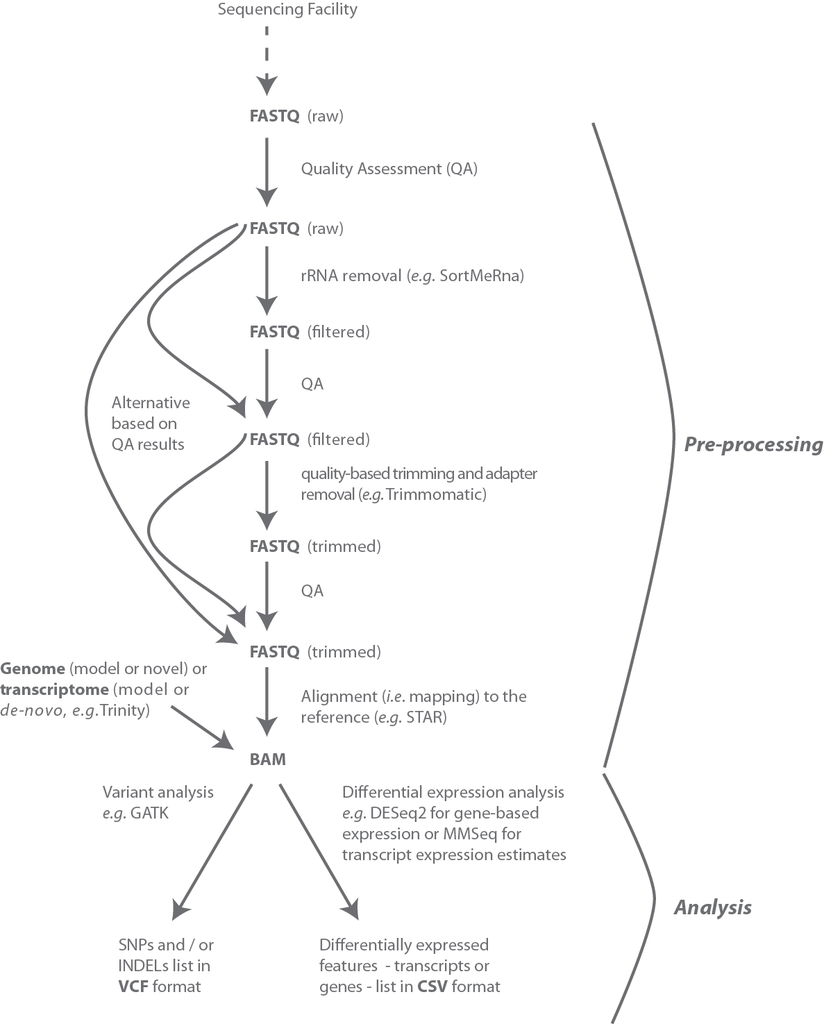

The pre-processing pipeline used during the course

## A word on the dataset that is used in this tutorial

As a running example, we use a dataset derived from a study performed in *P. tremula* (Robinson et al. 2014). The authors test the evolutionary theory suggesting that males and females may evolve sexually dimorphic phenotypic and biochemical traits concordant with each sex having different optimal strategies of resource investment to maximise reproductive success and fitness. Such sexual dimorphism should result in sex biased gene expression patterns in non-floral organs for autosomal genes associated with the control and development of such phenotypic traits. Hence, the authors, among other approaches have looked for gene expression differences between sex. This was achieved by an RNA-Seq differential expression analysis between samples grouped by sex. The samples have been sequenced on an Illumina HiSeq 2000, using TruSeq adapters, through a 101 cycles paired-end protocol, which yielded between 11 million and 34 million reads per sample.

In the following sections, we look at a subset of the data, corresponding to reads obtained from individuals of the RNA-seq experiment, and quantified against the *P. trichocarpa* reference. The reason we used the *P. trichocarpa* reference is that we are currently establishing the *P. tremula* genome. *P. trichocarpa* is a closely related species (the latter present in north-western america while the former grows in northern and central europe).

As a side note, reads were retrieved from the European Nucleotide Archive (ENA, accession ID ERP002471).

## A word on Integrated Development Environment (IDE)

There are numerous tools to support developing programs and softwares in *R*. For this course, we have selected one of them: the [RStudio](http://rstudio.org) environment, which provides a feature-full, user-friendly, cross-platform environment for working with *R*.

# References

Mortazavi, Ali, and others. 2008. “Mapping and Quantifying Mammalian Transcriptomes by RNA-Seq.” *Nature Methods* 5 (7): 621–8.

Robinson, Kathryn, Nicolas Delhomme, Niklas Mähler, Bastian Schiffthaler, Jenny Önskog, Benedicte Albrectsen, Pär Ingvarsson, Torgeir Hvidsten, Stefan Jansson, and Nathaniel Street. 2014. “Populus Tremula (European Aspen) Shows No Evidence of Sexual Dimorphism.” *BMC Plant Biology* 14 (1): 276–76. doi:10.1186/s12870-014-0276-5.

[^1]: Do not worry if some of this is illegible to you at present, it should be clear by the end of the workshop if we do our job
[^2]: See http://www.epigenesys.eu/images/stories/protocols/pdf/20150303161357_p67.pdf